# A3: Incarceration

### Introduction

The issue of racial discrimination in the course of law enforcement is often discussed. So I use the ratio of the population of the White people in jail (white_jail_pop) to all the White people (white_pop_15to64) and the ratio of the population of the Black people in jail (black_jail_pop) to all the Black people (black_pop_15to64) to analyze whether there is a racial discrimination happened in law enforcement.

### Summary Information

```r
source("https://raw.githubusercontent.com/info-201b-wi22/a3-incarceration-XiaoyuZhou000/main/summary.R?token=GHSAT0AAAAAABR6YVNLLT7W5XFODKWJZCDAYRCZ7IA")
max_rate <- max(data_year_clean$incarceration_rate_year)*100
min_rate <- min(data_year_clean$incarceration_rate_year)*100
num_black_rate <- as.numeric(black_rate)*100
num_white_rate <- as.numeric(white_rate)*100
max_diff_state <- max(data_difference$rate_diff_mean)*100
```

In 2018, the average incarceration rate of races was 0.381%, the annual highest rate in the country from 1970 to 2018. In 1971, the average incarceration rate of races was 0.063%, the annual lowest rate in the country from 1970 to 2018. The average incarceration rate of the Black people from 1970 to 2018 is 4.273%. The average incarceration rate of the White people from 1970 to 2018 is 0.304%. The UT has the highest difference of the incarceration rate of the White and the Black, which is 33.612%.

### The Dataset

Who collected the data?  
This work employed two Bureau of Justice Statistics (BJS) data collections: the Census of Jails (COJ), which covers all jails and is conducted every five to eight years since 1970, and the Annual Survey of Jails (ASJ), which covers about one-third of jails—and includes nearly all of the largest jails—that has been conducted in non-census years since 1982. This project was funded by the Robert W. Wilson Charitable Trust.

How was the data collected or generated? This dataset was assembled using information collected by the U.S. Department of Justice Bureau of Justice Statistics (BJS)

Why was the data collected? To explore the fairness of law enforcement

How many observations (rows) are in your data? 153811

How many features (columns) are in the data?  
121

What, if any, ethical questions or questions of power do you need to consider when working with this data?  
Whether the differences in educational attainment among each race also affect the disparities in incarceration rates among each race, not only the discrimination.

What are possible limitations or problems with this data? (at least 200 words) First of all, the integrity of the data was so huge that I had to constantly remove NA values when calculating the ratio. With such a large data loss, it’s hard to make our final results reliable. The Code Book also documents a large number of data losses. Secondly, the purpose of my investigation is to analyze whether there is racial discrimination in law enforcement by comparing the different incarceration rates of white and black people. But we don’t know what the educational rates are for different races. Education also has an effect on incarceration rates. So this data does not provide hard evidence for us to analyze whether racial discrimination exists.

### Trends Over Time Chart

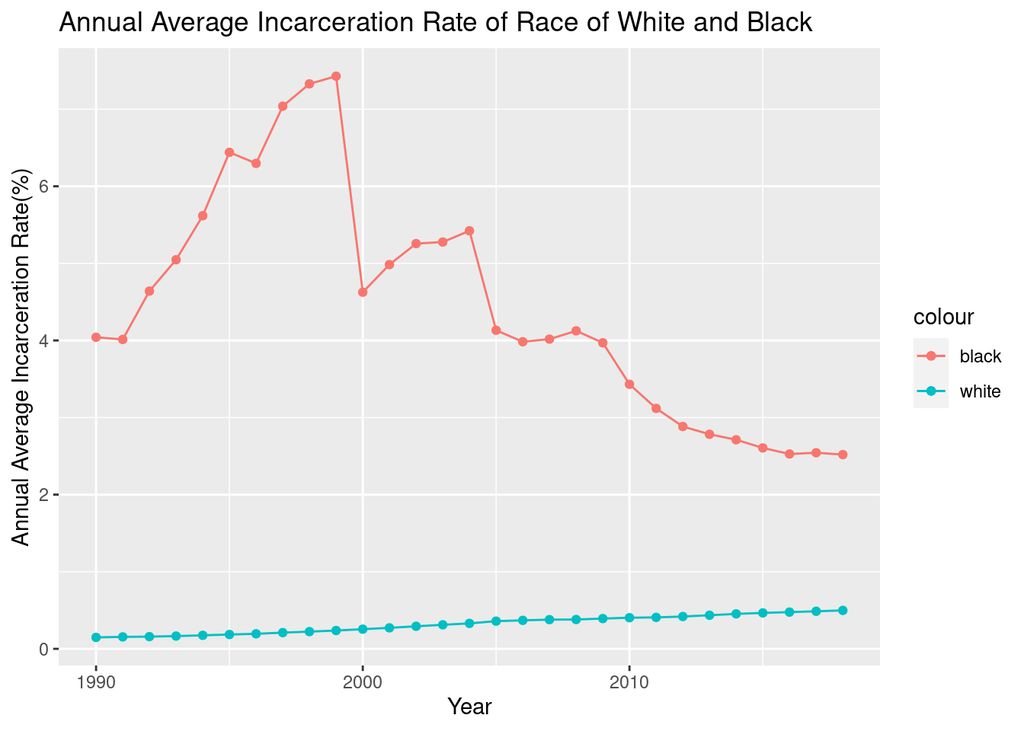

### Variable Comparison Chart

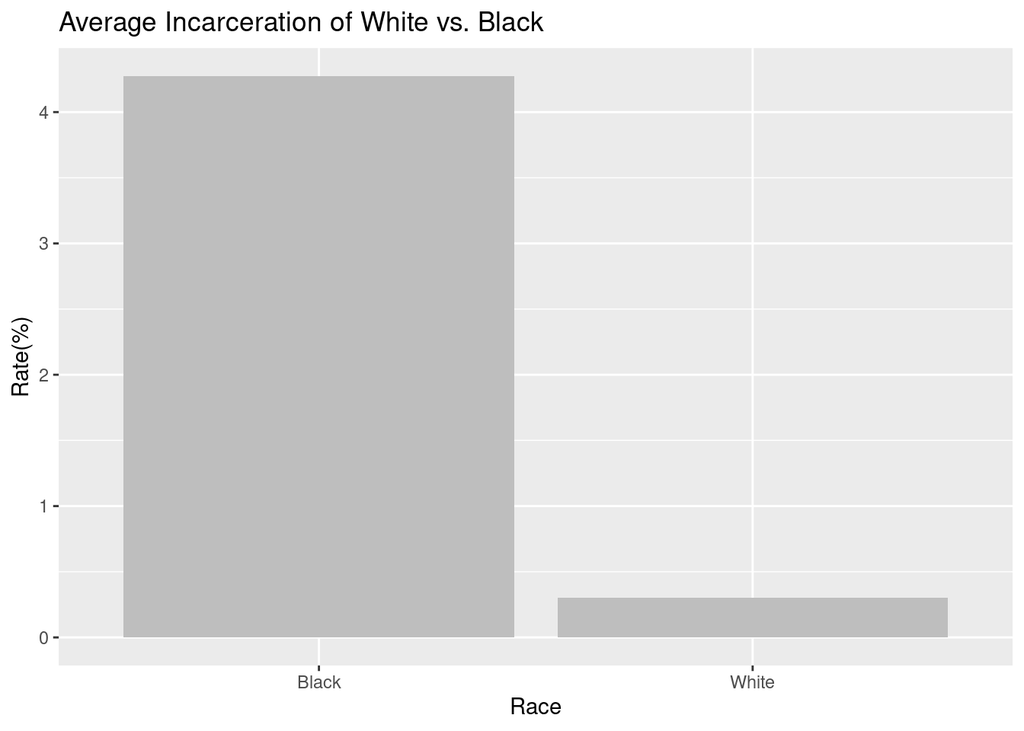

### Map

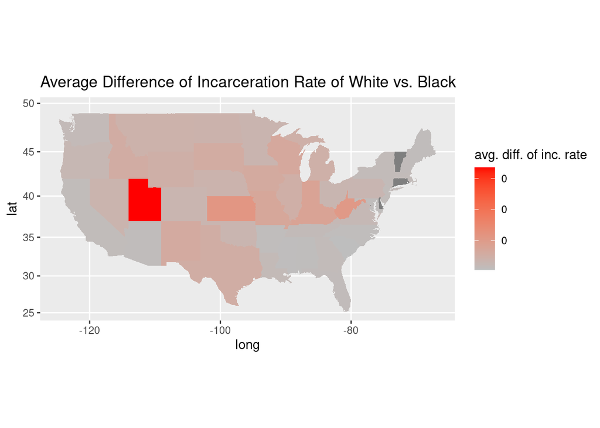

This map summarizes the differences between the White and Black incarceration rates in different states. UT has the highest difference obviously.